# DATA 607 - Project 2: Data Set 3

Julian Adames-Ng

2024-10-06

# Introduction

When working with data, you should expect to spend a good amount of time in the clean-up process, but it is not always ‘messy’ or unreadable. For example, data can still be organized in a data-frame in a way that is readable, but at the same time it may not be useful in such presented formats. In these cases, we may have to transpose the data-frame and re-organize to fit our needs.

## Loading Data: Creating the Initial Data-Frame

The data is loaded into a data-frame called ‘movies_df’.

```r
rm(list = ls())

movies_df <- data.frame(
  c('Young',NA,NA,'Old',NA),
  c('Liked','Disliked',NA,'Liked','Disliked'),
  c(23,77,NA,58,42),
  c(91,9,NA,14,86),
  c(76,24,NA,37,63)
)

colnames(movies_df) <- c('','','Iron Man','Titanic','Legally Blonde')

#view current state of data-frame
movies_df
```

```
##                  Iron Man Titanic Legally Blonde
## 1 Young    Liked       23      91             76
## 2  <NA> Disliked       77       9             24
## 3  <NA>     <NA>       NA      NA             NA
## 4   Old    Liked       58      14             37
## 5  <NA> Disliked       42      86             63
```

## Loading Data: Writing the Data-Frame to a CSV File

We can now write the ‘movies_df’ data-frame to a CSV file. Within the ‘write.csv()’ function, I specified the ‘row.names’ parameter to ‘FALSE’ to avoid creating non-blank row names. I also set the ‘na’ parameter to “” to replace all ‘NA’ values with blanks. The ‘stringsAsFactors’ parameter is set to ‘FALSE’ to avoid changing the character entries. At first glance it looks correct, but the data-frame still shows up with ‘NA’ values in some of the cells.

```r
#write to csv file
write.csv(movies_df, "movies.csv", row.names = FALSE, na = "")

#read from csv file into R
movies_csv <- read.csv('movies.csv', stringsAsFactors = FALSE, check.names = FALSE)

movies_csv
```

```
##                  Iron Man Titanic Legally Blonde
## 1 Young    Liked       23      91             76
## 2       Disliked       77       9             24
## 3                      NA      NA             NA
## 4   Old    Liked       58      14             37
## 5       Disliked       42      86             63
```

## Loading Data: Changing “NA” Values to Blanks

To remove the remaining ‘NA’ values I subset the data-frame and set any value that ‘is.na’ to ““. When calling the updated data, it seemed to have removed the blank row entirely. To confirm that this was not the case, I presented the data nicely using the ‘datatable()’ function.

```r
#change NA values to blank
movies_csv[is.na(movies_csv)] <- ""

#check updated data-frame
movies_csv
```

```
##                  Iron Man Titanic Legally Blonde
## 1 Young    Liked       23      91             76
## 2       Disliked       77       9             24
## 3
## 4   Old    Liked       58      14             37
## 5       Disliked       42      86             63
```

```r
# Display the data frame nicely
datatable(movies_csv)
```

|  | Var.2 | Var.3 | Iron Man | Titanic | Legally Blonde |
| --- | --- | --- | --- | --- | --- |
| 1 | Young | Liked | 23 | 91 | 76 |
| 2 |  | Disliked | 77 | 9 | 24 |
| 3 |  |  |  |  |  |
| 4 | Old | Liked | 58 | 14 | 37 |
| 5 |  | Disliked | 42 | 86 | 63 |

## Loading Data: Changing the Altered Column Names

```r
#specify additional options
datatable(movies_csv, options = list(columnDefs = list(list(targets = c(1, 2), title = ""))))
```

|  | Var.2 | Var.3 | Iron Man | Titanic | Legally Blonde |
| --- | --- | --- | --- | --- | --- |
| 1 | Young | Liked | 23 | 91 | 76 |
| 2 |  | Disliked | 77 | 9 | 24 |
| 3 |  |  |  |  |  |
| 4 | Old | Liked | 58 | 14 | 37 |
| 5 |  | Disliked | 42 | 86 | 63 |

## Using Valid Column Names

Before we can pivot, we need to change the column/variable names to a valid format. This means no white-spaces or special characters.

```r
#check data frame again
movies_csv
```

```
##                  Iron Man Titanic Legally Blonde
## 1 Young    Liked       23      91             76
## 2       Disliked       77       9             24
## 3
## 4   Old    Liked       58      14             37
## 5       Disliked       42      86             63
```

Here, I replace white-spaces with a period and labeled the first two columns that originally had blank titles as ‘Age_Group’ and ‘Preference’. For the blank row entries in the ‘Age_Group’ column, I labeled them according to the relevant age group.

```r
colnames(movies_csv) <- c('Age_Group','Preference','Iron.Man','Titanic','Legally.Blonde')

movies_csv$Age_Group[2] <- 'Young'
movies_csv$Age_Group[5] <- 'Old'

movies_csv
```

```
##   Age_Group Preference Iron.Man Titanic Legally.Blonde
## 1     Young      Liked       23      91             76
## 2     Young   Disliked       77       9             24
## 3
## 4       Old      Liked       58      14             37
## 5       Old   Disliked       42      86             63
```

## Pivoting

Now that all of the required data is loaded, we need to transform what we have so that it is readable to our liking. In this case, this means pivoting the matrix and aggregating values and columns. To avoid gaps in our pivoted data, I remove the blank row before applying the ‘pivot_longer()’ function.

```r
movies_csv <- movies_csv[-3, ]

p_movies <- pivot_longer(movies_csv,
                           cols = c('Iron.Man','Titanic','Legally.Blonde'),
                           names_to = "Movie",
                           values_to = "Ratings.Count")

p_movies
```

```
## # A tibble: 12 × 4
##    Age_Group Preference Movie          Ratings.Count
##    <chr>     <chr>      <chr>          <chr>
##  1 Young     Liked      Iron.Man       23
##  2 Young     Liked      Titanic        91
##  3 Young     Liked      Legally.Blonde 76
##  4 Young     Disliked   Iron.Man       77
##  5 Young     Disliked   Titanic        9
##  6 Young     Disliked   Legally.Blonde 24
##  7 Old       Liked      Iron.Man       58
##  8 Old       Liked      Titanic        14
##  9 Old       Liked      Legally.Blonde 37
## 10 Old       Disliked   Iron.Man       42
## 11 Old       Disliked   Titanic        86
## 12 Old       Disliked   Legally.Blonde 63
```

## Changing Column Type

We need to change the ‘Ratings.Count’ column to numeric values to perform mathematical operations. After doing so, we can group the data according to Age_Group, Movie, and Preference, in that order.

```r
p_movies$Ratings.Count <- as.numeric(p_movies$Ratings.Count)

#Aggregate data by city and airline
grouped_movies <- p_movies %>%
  group_by(Age_Group, Movie, Preference) %>%
  summarize(Ratings.Count, .groups = 'drop')

grouped_movies
```

```
## # A tibble: 12 × 4
##    Age_Group Movie          Preference Ratings.Count
##    <chr>     <chr>          <chr>              <dbl>
##  1 Old       Iron.Man       Disliked              42
##  2 Old       Iron.Man       Liked                 58
##  3 Old       Legally.Blonde Disliked              63
##  4 Old       Legally.Blonde Liked                 37
##  5 Old       Titanic        Disliked              86
##  6 Old       Titanic        Liked                 14
##  7 Young     Iron.Man       Disliked              77
##  8 Young     Iron.Man       Liked                 23
##  9 Young     Legally.Blonde Disliked              24
## 10 Young     Legally.Blonde Liked                 76
## 11 Young     Titanic        Disliked               9
## 12 Young     Titanic        Liked                 91
```

## Condensing the Data

As shown above, for each age group there are duplicate entries for each movie in order to match to either the ‘Liked’ or ‘Disliked’ preference. This gives us a data-frame with 12 rows. We can condense this down to just 6 rows by including the preference for each movie on the same row by creating a ‘Liked’ column and a ‘Disliked’ column.

```r
#present corresponding values for (on time) and (delayed) side by side
wide_movies <- grouped_movies %>%
  pivot_wider(names_from = Preference,
              values_from = Ratings.Count)

wide_movies
```

```
## # A tibble: 6 × 4
##   Age_Group Movie          Disliked Liked
##   <chr>     <chr>             <dbl> <dbl>
## 1 Old       Iron.Man             42    58
## 2 Old       Legally.Blonde       63    37
## 3 Old       Titanic              86    14
## 4 Young     Iron.Man             77    23
## 5 Young     Legally.Blonde       24    76
## 6 Young     Titanic               9    91
```

## Creating New Columns (1)

Now that we have data that is readable to our liking, we can create new columns to use for our analysis. Here, I created a column for the percentage of liked films relative to all ratings of each movie and corresponding to a specific age group.

```r
#create new column to show percentage of delayed flights for each row
wide_movies$pct_liked <- wide_movies$Liked / (wide_movies$Disliked + wide_movies$Liked)

wide_movies
```

```
## # A tibble: 6 × 5
##   Age_Group Movie          Disliked Liked pct_liked
##   <chr>     <chr>             <dbl> <dbl>     <dbl>
## 1 Old       Iron.Man             42    58      0.58
## 2 Old       Legally.Blonde       63    37      0.37
## 3 Old       Titanic              86    14      0.14
## 4 Young     Iron.Man             77    23      0.23
## 5 Young     Legally.Blonde       24    76      0.76
## 6 Young     Titanic               9    91      0.91
```

## Creating New Columns (2)

```r
mAge_liked <- wide_movies %>%
  group_by(Age_Group) %>%
  summarize(mean_liked = mean(Liked))

#mAge_liked

mLiked_Old <- mAge_liked$mean_liked[1]
mLiked_Young <- mAge_liked$mean_liked[2]

wide_movies$mean_liked <- NA

wide_movies$mean_liked <- ifelse(wide_movies$Age_Group == "Old", mLiked_Old, wide_movies$mean_liked)
wide_movies$mean_liked <- ifelse(wide_movies$Age_Group == "Young", mLiked_Young, wide_movies$mean_liked)

wide_movies
```

```
## # A tibble: 6 × 6
##   Age_Group Movie          Disliked Liked pct_liked mean_liked
##   <chr>     <chr>             <dbl> <dbl>     <dbl>      <dbl>
## 1 Old       Iron.Man             42    58      0.58       36.3
## 2 Old       Legally.Blonde       63    37      0.37       36.3
## 3 Old       Titanic              86    14      0.14       36.3
## 4 Young     Iron.Man             77    23      0.23       63.3
## 5 Young     Legally.Blonde       24    76      0.76       63.3
## 6 Young     Titanic               9    91      0.91       63.3
```

## Creating New Columns (3)

```r
mAge_total1 <- wide_movies %>%
   group_by(Age_Group) %>%
   summarize(liked_total = sum(Liked))

mAge_total <- wide_movies %>%
   group_by(Age_Group) %>%
   summarize(total = sum(Liked, Disliked))

mAge_total1
```

```
## # A tibble: 2 × 2
##   Age_Group liked_total
##   <chr>           <dbl>
## 1 Old               109
## 2 Young             190
```

```r
mAge_total
```

```
## # A tibble: 2 × 2
##   Age_Group total
##   <chr>     <dbl>
## 1 Old         300
## 2 Young       300
```

```r
mlike_old <- mAge_total1$liked_total[1]
mlike_young <- mAge_total1$liked_total[2]

mTot_old <- mAge_total$total[1]
mTot_young <- mAge_total$total[2]

wide_movies$liked_total <- NA
wide_movies$total <- NA

wide_movies$liked_total <- ifelse(wide_movies$Age_Group == "Old", mlike_old, wide_movies$liked_total)
wide_movies$liked_total <- ifelse(wide_movies$Age_Group == "Young", mlike_young, wide_movies$liked_total)

wide_movies$total <- ifelse(wide_movies$Age_Group == "Old", mTot_old, wide_movies$total)
wide_movies$total <- ifelse(wide_movies$Age_Group == "Young", mTot_young, wide_movies$total)

wide_movies$age_liked_pct <- wide_movies$liked_total / wide_movies$total

wide_movies$pct_mean_liked <- NA

wide_movies$pct_mean_liked <- wide_movies$mean_liked / wide_movies$total

wide_movies
```

```
## # A tibble: 6 × 10
##   Age_Group Movie          Disliked Liked pct_liked mean_liked liked_total total
##   <chr>     <chr>             <dbl> <dbl>     <dbl>      <dbl>       <dbl> <dbl>
## 1 Old       Iron.Man             42    58      0.58       36.3         109   300
## 2 Old       Legally.Blonde       63    37      0.37       36.3         109   300
## 3 Old       Titanic              86    14      0.14       36.3         109   300
## 4 Young     Iron.Man             77    23      0.23       63.3         190   300
## 5 Young     Legally.Blonde       24    76      0.76       63.3         190   300
## 6 Young     Titanic               9    91      0.91       63.3         190   300
## # ℹ 2 more variables: age_liked_pct <dbl>, pct_mean_liked <dbl>
```

## Analysis

In my analysis, I decided to find the sample standard deviation based on the percentage points that I computed for the individual movies and the percentages of the means. I did this to compare the liked ratings according to variation in the data set.

```r
sample_pct_sd <- wide_movies %>%
   group_by(Age_Group) %>%
   reframe(pct_liked, pct_mean_liked)

sample_pct_sd$sq_diff <- (sample_pct_sd$pct_liked - sample_pct_sd$pct_mean_liked)^2


sample_pct_sd1 <- sample_pct_sd %>%
  group_by(Age_Group) %>%
  summarize(pct_sd = sqrt(sum(sq_diff)/(5 - 1)))

#sample_pct_sd1

#standard deviation of delay percentages for old people
old_pct_sd <- sample_pct_sd1$pct_sd[1]

#standard deviation of delay percentages for young people
young_pct_sd <- sample_pct_sd1$pct_sd[2]

liked_df <- data.frame(Age_Group = wide_movies$Age_Group,
                 Movie = wide_movies$Movie,
                 Liked = wide_movies$Liked,
                 Pct_Liked = wide_movies$pct_liked,
                 #Mean_Pct_Delay = wide_flights$pct_mean_delayed,
                 #Pct_SD = round(sqrt(((wide_flights$pct_delayed - wide_flights$pct_mean_delayed)^2) / (wide_flights$total - 1)), 5),
                 #Avg_Pct_SD = NA,
                 Pct_SD = NA,
                 Age_Liked_Pct = wide_movies$age_liked_pct
                 )

liked_df$Pct_SD <- ifelse(wide_movies$Age_Group == "Old", old_pct_sd, liked_df$Pct_SD)
liked_df$Pct_SD <- ifelse(wide_movies$Age_Group == "Young", young_pct_sd, liked_df$Pct_SD)

#write to csv
write.csv(liked_df, 'movie_analysis.csv')

movies_analysis <- read.csv('movie_analysis.csv')

movies_analysis
```

```
##   X Age_Group          Movie Liked Pct_Liked    Pct_SD Age_Liked_Pct
## 1 1       Old       Iron.Man    58      0.58 0.2611903     0.3633333
## 2 2       Old Legally.Blonde    37      0.37 0.2611903     0.3633333
## 3 3       Old        Titanic    14      0.14 0.2611903     0.3633333
## 4 4     Young       Iron.Man    23      0.23 0.4444326     0.6333333
## 5 5     Young Legally.Blonde    76      0.76 0.4444326     0.6333333
## 6 6     Young        Titanic    91      0.91 0.4444326     0.6333333
```

## Visualizing Liked Percentages with Error Bars

The graphs below show the percentages of liked movies in two different ways. Both visuals include error bars that show the variability of the data.

### (1) Grouped by Age

Here we see the age groups bunched in two graphs, each with the liked percentages of the individual movies.

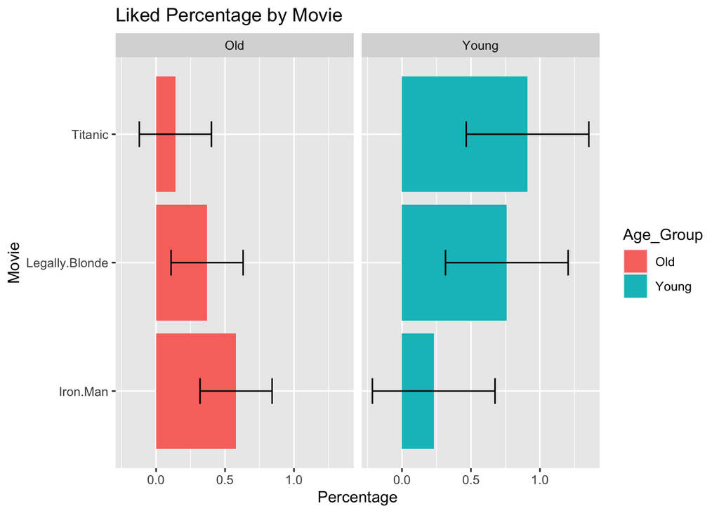

```r
ggplot(movies_analysis, aes(x = Pct_Liked, y = Movie, fill = Age_Group)) +
  facet_wrap(~ Age_Group) +
  geom_bar(stat = "identity") +
  geom_errorbar(aes(xmin = Pct_Liked - Pct_SD, xmax = Pct_Liked + Pct_SD), width = 0.2) +
  labs(
    title = "Liked Percentage by Movie",
    x = "Percentage",
    y = "Movie"
  )
```

### (2) Grouped by Movie

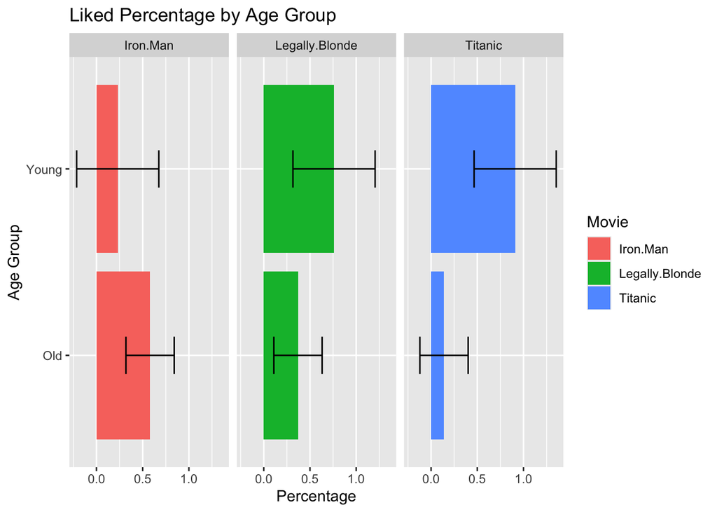

```r
ggplot(movies_analysis, aes(x = Pct_Liked, y = Age_Group, fill = Movie)) +
  facet_wrap(~ Movie) +
  geom_bar(stat = "identity") +
  geom_errorbar(aes(xmin = Pct_Liked - Pct_SD, xmax = Pct_Liked + Pct_SD), width = 0.2) +
  labs(
    title = "Liked Percentage by Age Group",
    x = "Percentage",
    y = "Age Group"
  )
```

## Overall Liked Percentage vs Age Group

Below I compared the overall liked ratings for each age group and used a bar graph to compare. It is clear that significantly less older people liked movies relative to the total number of ratings across all movies.

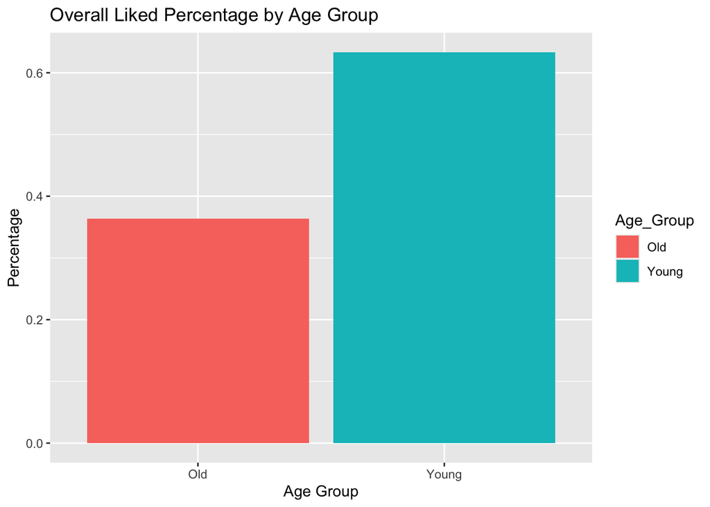

```r
liked_group <- movies_analysis %>%
   group_by(Age_Group) %>%
   summarize(age_liked_p = mean(Age_Liked_Pct))

ggplot(liked_group, aes(x = Age_Group, y = age_liked_p, fill = Age_Group)) +
  geom_bar(stat = "identity") +
  labs(
    title = "Overall Liked Percentage by Age Group",
    x = "Age Group",
    y = "Percentage"
  )
```

## Individual Liked Percentage vs Age Group (color filered by movie)

When breaking down the percentage comparison by movie, I visualized it as (1) a single stacked graph with the information for all movie and (2) as separate graphs for each movie. In either case, we see a significant difference in preferences across age groups.

### (1) Stacked (One Graph)

Here the graph is visually appealing, but may be harder to compare as the bars representing the preference for each movie are not properly aligned side by side.

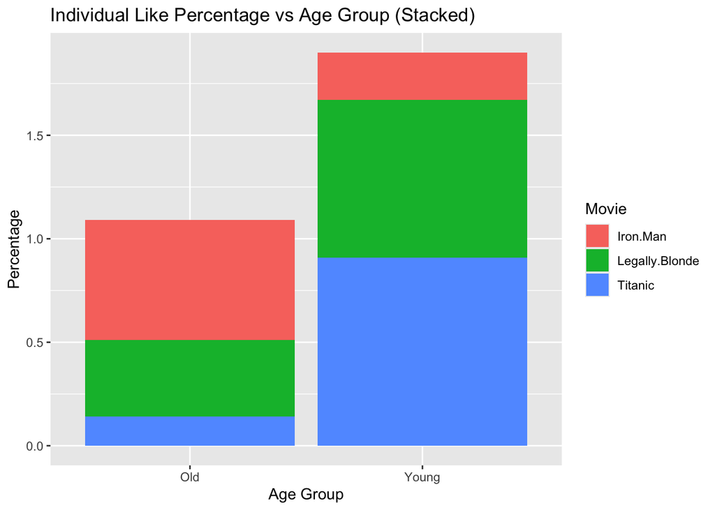

```r
ggplot(movies_analysis, aes(x = Age_Group, y = Pct_Liked, fill = Movie)) +
  geom_bar(stat = "identity", position = "stack") +
  labs(
    title = "Individual Like Percentage vs Age Group (Stacked)",
    x = "Age Group",
    y = "Percentage"
  )
```

### (2) Facet Wrap (Separate Graphs)

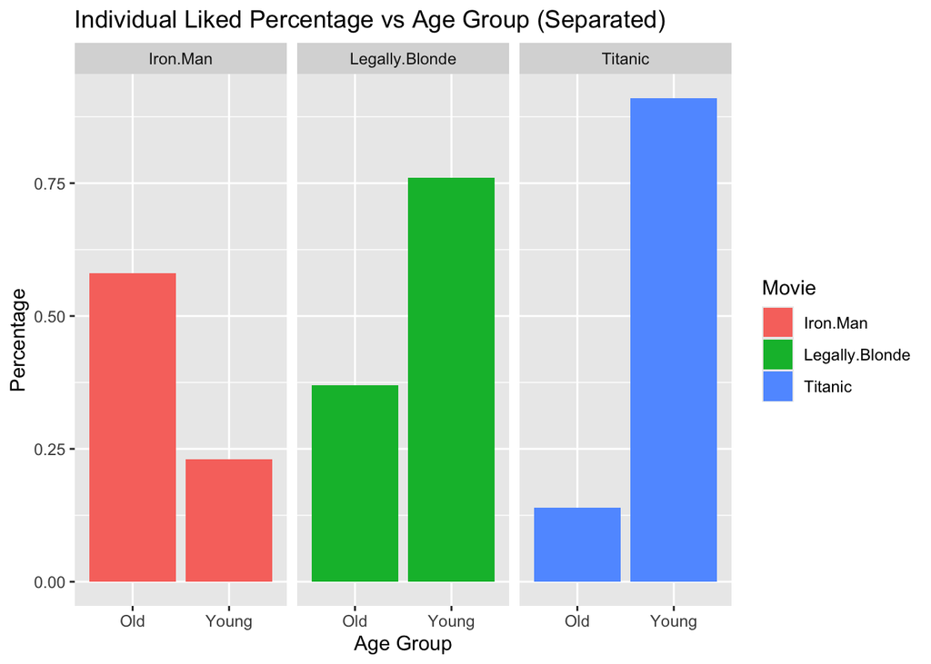

```r
ggplot(movies_analysis, aes(x = Age_Group, y = Pct_Liked, fill = Movie)) +
  facet_wrap(~ Movie) +
  geom_bar(stat = "identity") +
  labs(
    title = "Individual Liked Percentage vs Age Group (Separated)",
    x = "Age Group",
    y = "Percentage"
  )
```

## Like Percentage vs Movie (color filtered by Age Group)

I likewise visualized it by comparing the like percentages of each movie and filled by age group. I also swapped the axes for better readability.

### (1) Stacked (One Graph)

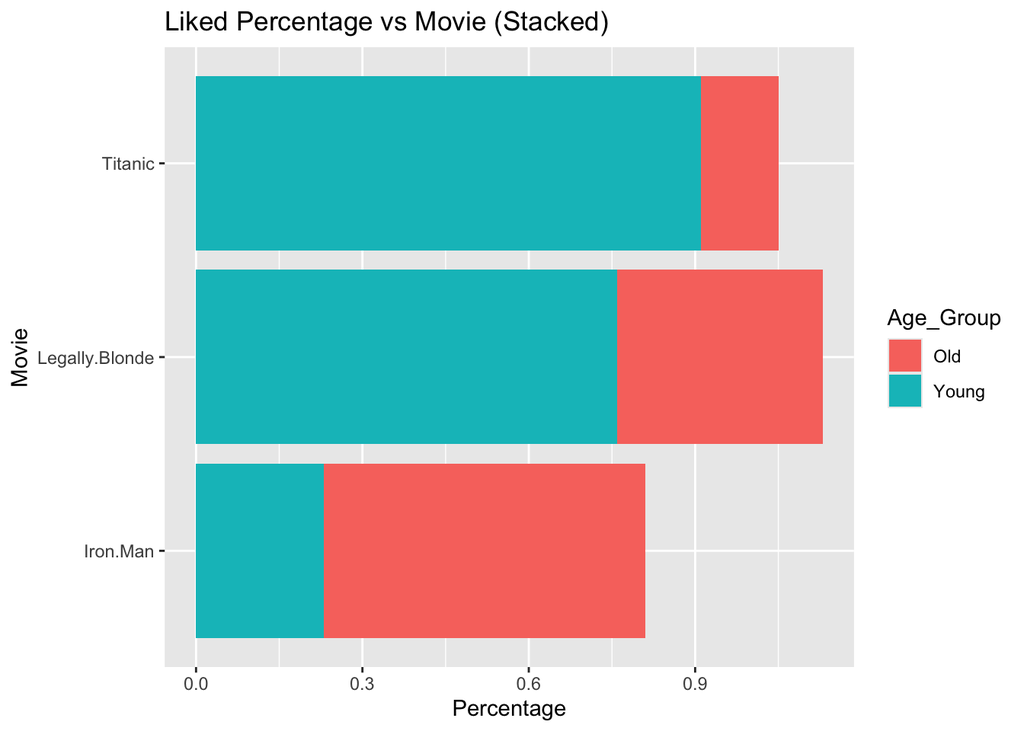

```r
ggplot(movies_analysis, aes(x = Pct_Liked, y = Movie, fill = Age_Group)) +
  geom_bar(stat = 'identity') +
  labs(
    title = "Liked Percentage vs Movie (Stacked)",
    x = "Percentage",
    y = "Movie"
  )
```

### (2) Facet Wrap (Separate Graphs)

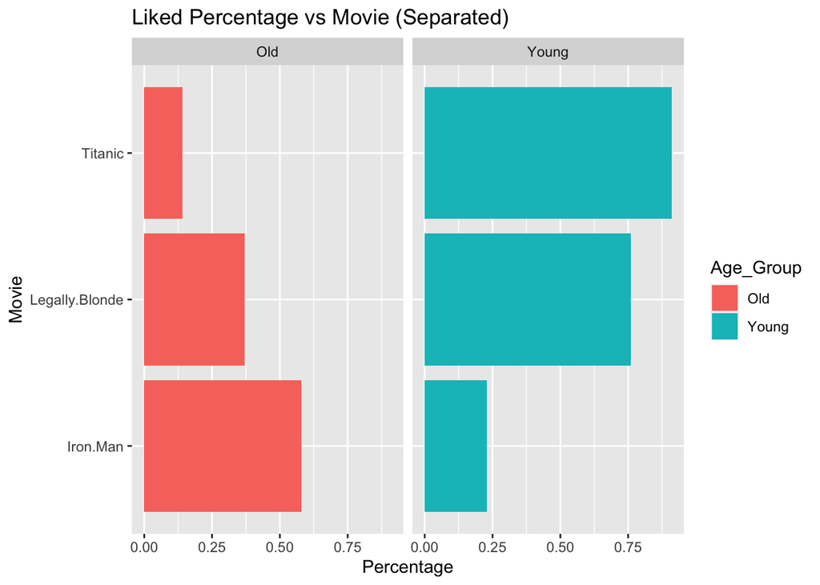

```r
ggplot(movies_analysis, aes(x = Pct_Liked, y = Movie, fill = Age_Group)) +
  facet_wrap(~ Age_Group) +
  geom_bar(stat = 'identity') +
  labs(
    title = "Liked Percentage vs Movie (Separated)",
    x = "Percentage",
    y = "Movie"
  )
```